# PROJECT : Analysis of the trip data of Ford GoBike, a bike-sharing system that covered the greater San Francisco Bay area from June 2017 to till April 2019.

## BY : Oluwadamilare Caleb Fabiyi

# INTRODUCTION

> The dataset is the trip data of Ford GoBike, a regional public bicycle sharing system that covered the California's San Francisco Bay Area, one of the largest bike-sharing system in the US.

> This is an exploration and analysis of a dataset containing Ford GoBike's trip data covering the period from 28 June 2017 to 30 April 2019.

> Data can be downloaded [here](https://s3.amazonaws.com/baywheels-data/index.html) and data description is provided [here](https://www.lyft.com/bikes/bay-wheels/system-data) .

# DATA WRANGLING

> **In this section of the report, I will gather my dataset, assess it carefully visually and programmatically and i will perform any necessary data cleaning.**

## 1) DATA GATHERING

> **I got my data from Ford GoBike's open repository [here](https://s3.amazonaws.com/baywheels-data/index.html)**

## Importing Packages

```python
# Importing all packages and setting plots to b embedded inline
import pandas as pd
import numpy as np
import matplotlib.pyplot as plt
import seaborn as sns
import matplotlib.patches as mpatches
from matplotlib import rcParams
import datetime
from scipy import stats
import os
import glob
from geopy.distance import geodesic


%matplotlib inline
```

## Loading Data - Loading directly downloaded CSVs using pandas

```python
#Load data from directory using pandas
folder_name = './fordgobike'
files = glob.glob(os.path.join(folder_name, '*.csv'))
bike_df = pd.concat((pd.read_csv(f, low_memory=False) for f in files), ignore_index = True)
```

```python
# Overview of data shape and composition
print('Shape:{}\n'.format(bike_df.shape))
print(bike_df.info())
print()
bike_df.head()
```

```
Shape:(3254325, 14)

<class 'pandas.core.frame.DataFrame'>
RangeIndex: 3254325 entries, 0 to 3254324
Data columns (total 14 columns):
 #   Column                   Dtype
---  ------                   -----
 0   duration_sec             int64
 1   start_time               object
 2   end_time                 object
 3   start_station_id         float64
 4   start_station_name       object
 5   start_station_latitude   float64
 6   start_station_longitude  float64
 7   end_station_id           float64
 8   end_station_name         object
 9   end_station_latitude     float64
 10  end_station_longitude    float64
 11  bike_id                  int64
 12  user_type                object
 13  bike_share_for_all_trip  object
dtypes: float64(6), int64(2), object(6)
memory usage: 347.6+ MB
None
```

|  | duration_sec | start_time | end_time | start_station_id | start_station_name | start_station_latitude | start_station_longitude | end_station_id | end_station_name | end_station_latitude | end_station_longitude | bike_id | user_type | bike_share_for_all_trip |
| --- | --- | --- | --- | --- | --- | --- | --- | --- | --- | --- | --- | --- | --- | --- |
| 0 | 80110 | 2017-12-31 16:57:39.6540 | 2018-01-01 15:12:50.2450 | 74.0 | Laguna St at Hayes St | 37.776435 | -122.426244 | 43.0 | San Francisco Public Library (Grove St at Hyde... | 37.778768 | -122.415929 | 96 | Customer | NaN |
| 1 | 78800 | 2017-12-31 15:56:34.8420 | 2018-01-01 13:49:55.6170 | 284.0 | Yerba Buena Center for the Arts (Howard St at ... | 37.784872 | -122.400876 | 96.0 | Dolores St at 15th St | 37.766210 | -122.426614 | 88 | Customer | NaN |
| 2 | 45768 | 2017-12-31 22:45:48.4110 | 2018-01-01 11:28:36.8830 | 245.0 | Downtown Berkeley BART | 37.870348 | -122.267764 | 245.0 | Downtown Berkeley BART | 37.870348 | -122.267764 | 1094 | Customer | NaN |
| 3 | 62172 | 2017-12-31 17:31:10.6360 | 2018-01-01 10:47:23.5310 | 60.0 | 8th St at Ringold St | 37.774520 | -122.409449 | 5.0 | Powell St BART Station (Market St at 5th St) | 37.783899 | -122.408445 | 2831 | Customer | NaN |
| 4 | 43603 | 2017-12-31 14:23:14.0010 | 2018-01-01 02:29:57.5710 | 239.0 | Bancroft Way at Telegraph Ave | 37.868813 | -122.258764 | 247.0 | Fulton St at Bancroft Way | 37.867789 | -122.265896 | 3167 | Subscriber | NaN |

**Our data was loaded properly into a pandas dataframe `bike_df`**

## Save Gathered data if not saved

```python
#Save pandas dataframe in CSV format so as not to repeat gathering
bike_df.to_csv('bike_df.csv', index=False)
```

```python
# Read the dataframe
bike_df = pd.read_csv('bike_df.csv', low_memory=False)
```

## 2) DATA ASSESSMENT

### **I will be assessing my data both visually and programmatically for quality and tidyness.**

**Quality**

Data that has issues with data content.

> - Missing data
> - Duplicate data
> - Invalid data
> - Inaccurate data.

**Tidyness**

Data that has issues with its structure, like rows, columns and table.

> - Each Variable forms a column
> - Each Obserevation forms a row
> - Each type of observational unit forms a table

**Data Assesssment Dimensions**

> - COMPLETENESS - Missing data.
> - VALIDITY - Conformation of data to pre-established schema.
> - ACCURACY - Appropriateness of data even though it conforms to schema.
> - CONSISITENCY - Representation of data to a standard format.

## A) Visual Assessment: Getting acquainted with data.

The dataset we will be using for this analysis was gotten from Baywheel official data repository.

The data will be visually assessed below for quality and tidyness.

```python
#Preview the data
bike_df.sample(5)
```

|  | duration_sec | start_time | end_time | start_station_id | start_station_name | start_station_latitude | start_station_longitude | end_station_id | end_station_name | end_station_latitude | end_station_longitude | bike_id | user_type | bike_share_for_all_trip |
| --- | --- | --- | --- | --- | --- | --- | --- | --- | --- | --- | --- | --- | --- | --- |
| 203146 | 628 | 2017-10-26 04:29:58.2410 | 2017-10-26 04:40:26.3200 | 134.0 | Valencia St at 24th St | 37.752428 | -122.420628 | 78.0 | Folsom St at 9th St | 37.773717 | -122.411647 | 2801 | Subscriber | NaN |
| 300244 | 379 | 2017-09-28 09:16:05.6010 | 2017-09-28 09:22:25.3890 | 67.0 | San Francisco Caltrain Station 2 (Townsend St... | 37.776639 | -122.395526 | 114.0 | Rhode Island St at 17th St | 37.764478 | -122.402570 | 121 | Subscriber | NaN |
| 1643591 | 198 | 2018-08-14 20:11:40.0700 | 2018-08-14 20:14:58.3610 | 238.0 | MLK Jr Way at University Ave | 37.871719 | -122.273068 | 246.0 | Berkeley Civic Center | 37.869060 | -122.270556 | 1287 | Subscriber | No |
| 1946071 | 425 | 2018-10-26 20:55:43.7120 | 2018-10-26 21:02:48.7250 | 16.0 | Steuart St at Market St | 37.794130 | -122.394430 | 6.0 | The Embarcadero at Sansome St | 37.804770 | -122.403234 | 1824 | Subscriber | No |
| 1391478 | 260 | 2018-07-24 08:09:57.2640 | 2018-07-24 08:14:17.6830 | 67.0 | San Francisco Caltrain Station 2 (Townsend St... | 37.776639 | -122.395526 | 90.0 | Townsend St at 7th St | 37.771058 | -122.402717 | 3077 | Subscriber | No |

```python
#Preview the first 5 rows
bike_df.head(5)
```

|  | duration_sec | start_time | end_time | start_station_id | start_station_name | start_station_latitude | start_station_longitude | end_station_id | end_station_name | end_station_latitude | end_station_longitude | bike_id | user_type | bike_share_for_all_trip |
| --- | --- | --- | --- | --- | --- | --- | --- | --- | --- | --- | --- | --- | --- | --- |
| 0 | 80110 | 2017-12-31 16:57:39.6540 | 2018-01-01 15:12:50.2450 | 74.0 | Laguna St at Hayes St | 37.776435 | -122.426244 | 43.0 | San Francisco Public Library (Grove St at Hyde... | 37.778768 | -122.415929 | 96 | Customer | NaN |
| 1 | 78800 | 2017-12-31 15:56:34.8420 | 2018-01-01 13:49:55.6170 | 284.0 | Yerba Buena Center for the Arts (Howard St at ... | 37.784872 | -122.400876 | 96.0 | Dolores St at 15th St | 37.766210 | -122.426614 | 88 | Customer | NaN |
| 2 | 45768 | 2017-12-31 22:45:48.4110 | 2018-01-01 11:28:36.8830 | 245.0 | Downtown Berkeley BART | 37.870348 | -122.267764 | 245.0 | Downtown Berkeley BART | 37.870348 | -122.267764 | 1094 | Customer | NaN |
| 3 | 62172 | 2017-12-31 17:31:10.6360 | 2018-01-01 10:47:23.5310 | 60.0 | 8th St at Ringold St | 37.774520 | -122.409449 | 5.0 | Powell St BART Station (Market St at 5th St) | 37.783899 | -122.408445 | 2831 | Customer | NaN |
| 4 | 43603 | 2017-12-31 14:23:14.0010 | 2018-01-01 02:29:57.5710 | 239.0 | Bancroft Way at Telegraph Ave | 37.868813 | -122.258764 | 247.0 | Fulton St at Bancroft Way | 37.867789 | -122.265896 | 3167 | Subscriber | NaN |

```python
#Preview the last 5 rows
bike_df.tail(5)
```

|  | duration_sec | start_time | end_time | start_station_id | start_station_name | start_station_latitude | start_station_longitude | end_station_id | end_station_name | end_station_latitude | end_station_longitude | bike_id | user_type | bike_share_for_all_trip |
| --- | --- | --- | --- | --- | --- | --- | --- | --- | --- | --- | --- | --- | --- | --- |
| 3254320 | 184 | 2019-04-01 00:09:17.5660 | 2019-04-01 00:12:22.5170 | 133.0 | Valencia St at 22nd St | 37.755213 | -122.420975 | 132.0 | 24th St at Chattanooga St | 37.751819 | -122.426614 | 6430 | Subscriber | No |
| 3254321 | 539 | 2019-04-01 00:03:02.5730 | 2019-04-01 00:12:02.0670 | 78.0 | Folsom St at 9th St | 37.773717 | -122.411647 | 77.0 | 11th St at Natoma St | 37.773507 | -122.416040 | 4972 | Subscriber | Yes |
| 3254322 | 292 | 2019-04-01 00:06:04.2370 | 2019-04-01 00:10:56.9850 | 243.0 | Bancroft Way at College Ave | 37.869360 | -122.254337 | 269.0 | Telegraph Ave at Carleton St | 37.862320 | -122.258801 | 3415 | Subscriber | Yes |
| 3254323 | 471 | 2019-04-01 00:01:38.4110 | 2019-04-01 00:09:29.9650 | 370.0 | Jones St at Post St | 37.787327 | -122.413278 | 43.0 | San Francisco Public Library (Grove St at Hyde... | 37.778768 | -122.415929 | 5018 | Subscriber | Yes |
| 3254324 | 356 | 2019-04-01 00:00:28.7290 | 2019-04-01 00:06:25.0650 | 14.0 | Clay St at Battery St | 37.795001 | -122.399970 | 371.0 | Lombard St at Columbus Ave | 37.802746 | -122.413579 | 5956 | Subscriber | No |

### Observation

**I did my visual assessment of by sampling the data randomly here in jupyter notebook as the datset is quite heavy for excel or my jupyter lab**

#### Quality issues

None observed

#### Tidiness issues

None observed

## B) Programmatic Assessment: Using pandas functions and methods to assess our data.

The data will be programmatically assessed below for quality and tidyness.

```python
#Preview the first 5 rows
bike_df.head(5)
```

|  | duration_sec | start_time | end_time | start_station_id | start_station_name | start_station_latitude | start_station_longitude | end_station_id | end_station_name | end_station_latitude | end_station_longitude | bike_id | user_type | bike_share_for_all_trip |
| --- | --- | --- | --- | --- | --- | --- | --- | --- | --- | --- | --- | --- | --- | --- |
| 0 | 80110 | 2017-12-31 16:57:39.6540 | 2018-01-01 15:12:50.2450 | 74.0 | Laguna St at Hayes St | 37.776435 | -122.426244 | 43.0 | San Francisco Public Library (Grove St at Hyde... | 37.778768 | -122.415929 | 96 | Customer | NaN |
| 1 | 78800 | 2017-12-31 15:56:34.8420 | 2018-01-01 13:49:55.6170 | 284.0 | Yerba Buena Center for the Arts (Howard St at ... | 37.784872 | -122.400876 | 96.0 | Dolores St at 15th St | 37.766210 | -122.426614 | 88 | Customer | NaN |
| 2 | 45768 | 2017-12-31 22:45:48.4110 | 2018-01-01 11:28:36.8830 | 245.0 | Downtown Berkeley BART | 37.870348 | -122.267764 | 245.0 | Downtown Berkeley BART | 37.870348 | -122.267764 | 1094 | Customer | NaN |
| 3 | 62172 | 2017-12-31 17:31:10.6360 | 2018-01-01 10:47:23.5310 | 60.0 | 8th St at Ringold St | 37.774520 | -122.409449 | 5.0 | Powell St BART Station (Market St at 5th St) | 37.783899 | -122.408445 | 2831 | Customer | NaN |
| 4 | 43603 | 2017-12-31 14:23:14.0010 | 2018-01-01 02:29:57.5710 | 239.0 | Bancroft Way at Telegraph Ave | 37.868813 | -122.258764 | 247.0 | Fulton St at Bancroft Way | 37.867789 | -122.265896 | 3167 | Subscriber | NaN |

```python
#Preview the last 5 rows
bike_df.tail(5)
```

|  | duration_sec | start_time | end_time | start_station_id | start_station_name | start_station_latitude | start_station_longitude | end_station_id | end_station_name | end_station_latitude | end_station_longitude | bike_id | user_type | bike_share_for_all_trip |
| --- | --- | --- | --- | --- | --- | --- | --- | --- | --- | --- | --- | --- | --- | --- |
| 3254320 | 184 | 2019-04-01 00:09:17.5660 | 2019-04-01 00:12:22.5170 | 133.0 | Valencia St at 22nd St | 37.755213 | -122.420975 | 132.0 | 24th St at Chattanooga St | 37.751819 | -122.426614 | 6430 | Subscriber | No |
| 3254321 | 539 | 2019-04-01 00:03:02.5730 | 2019-04-01 00:12:02.0670 | 78.0 | Folsom St at 9th St | 37.773717 | -122.411647 | 77.0 | 11th St at Natoma St | 37.773507 | -122.416040 | 4972 | Subscriber | Yes |
| 3254322 | 292 | 2019-04-01 00:06:04.2370 | 2019-04-01 00:10:56.9850 | 243.0 | Bancroft Way at College Ave | 37.869360 | -122.254337 | 269.0 | Telegraph Ave at Carleton St | 37.862320 | -122.258801 | 3415 | Subscriber | Yes |
| 3254323 | 471 | 2019-04-01 00:01:38.4110 | 2019-04-01 00:09:29.9650 | 370.0 | Jones St at Post St | 37.787327 | -122.413278 | 43.0 | San Francisco Public Library (Grove St at Hyde... | 37.778768 | -122.415929 | 5018 | Subscriber | Yes |
| 3254324 | 356 | 2019-04-01 00:00:28.7290 | 2019-04-01 00:06:25.0650 | 14.0 | Clay St at Battery St | 37.795001 | -122.399970 | 371.0 | Lombard St at Columbus Ave | 37.802746 | -122.413579 | 5956 | Subscriber | No |

```python
#Check 10 random rows
bike_df.sample(10)
```

|  | duration_sec | start_time | end_time | start_station_id | start_station_name | start_station_latitude | start_station_longitude | end_station_id | end_station_name | end_station_latitude | end_station_longitude | bike_id | user_type | bike_share_for_all_trip |
| --- | --- | --- | --- | --- | --- | --- | --- | --- | --- | --- | --- | --- | --- | --- |
| 1440079 | 193 | 2018-07-16 21:34:22.1630 | 2018-07-16 21:37:35.7460 | 239.0 | Bancroft Way at Telegraph Ave | 37.868813 | -122.258764 | 245.0 | Downtown Berkeley BART | 37.870348 | -122.267764 | 3311 | Subscriber | No |
| 220271 | 12378 | 2017-10-21 10:04:27.1600 | 2017-10-21 13:30:45.4710 | 6.0 | The Embarcadero at Sansome St | 37.804770 | -122.403234 | 70.0 | Central Ave at Fell St | 37.773311 | -122.444293 | 2418 | Customer | NaN |
| 652778 | 342 | 2018-02-17 11:29:35.1770 | 2018-02-17 11:35:17.7880 | 239.0 | Bancroft Way at Telegraph Ave | 37.868813 | -122.258764 | 247.0 | Fulton St at Bancroft Way | 37.867789 | -122.265896 | 2871 | Customer | No |
| 2279930 | 1091 | 2018-12-21 15:41:18.5740 | 2018-12-21 15:59:29.8590 | 361.0 | Mendell St at Fairfax Ave | 37.739853 | -122.385655 | 104.0 | 4th St at 16th St | 37.767045 | -122.390833 | 2790 | Customer | No |
| 541369 | 288 | 2018-01-26 08:01:08.9660 | 2018-01-26 08:05:57.4790 | 243.0 | Bancroft Way at College Ave | 37.869360 | -122.254337 | 245.0 | Downtown Berkeley BART | 37.870348 | -122.267764 | 3604 | Subscriber | No |
| 1485364 | 854 | 2018-07-10 09:29:26.2730 | 2018-07-10 09:43:40.3710 | 30.0 | San Francisco Caltrain (Townsend St at 4th St) | 37.776598 | -122.395282 | 8.0 | The Embarcadero at Vallejo St | 37.799953 | -122.398525 | 167 | Subscriber | No |
| 1203646 | 452 | 2018-06-21 21:03:43.8720 | 2018-06-21 21:11:16.4940 | 183.0 | Telegraph Ave at 19th St | 37.808702 | -122.269927 | 159.0 | 24th St at Market St | 37.816060 | -122.278244 | 2382 | Subscriber | No |
| 2284106 | 1004 | 2018-12-20 17:35:34.4720 | 2018-12-20 17:52:18.9980 | 126.0 | Esprit Park | 37.761634 | -122.390648 | 59.0 | S Van Ness Ave at Market St | 37.774814 | -122.418954 | 5567 | Customer | No |
| 1824701 | 452 | 2018-09-16 13:09:38.9110 | 2018-09-16 13:17:11.4370 | 16.0 | Steuart St at Market St | 37.794130 | -122.394430 | 19.0 | Post St at Kearny St | 37.788975 | -122.403452 | 3972 | Subscriber | Yes |
| 2768602 | 2574 | 2019-03-30 15:14:35.6320 | 2019-03-30 15:57:30.5930 | 15.0 | San Francisco Ferry Building (Harry Bridges Pl... | 37.795392 | -122.394203 | 20.0 | Mechanics Monument Plaza (Market St at Bush St) | 37.791300 | -122.399051 | 6186 | Customer | No |

```python
#Check an overview of the columns
bike_df.info()
```

```
<class 'pandas.core.frame.DataFrame'>
RangeIndex: 3254325 entries, 0 to 3254324
Data columns (total 14 columns):
 #   Column                   Dtype
---  ------                   -----
 0   duration_sec             int64
 1   start_time               object
 2   end_time                 object
 3   start_station_id         float64
 4   start_station_name       object
 5   start_station_latitude   float64
 6   start_station_longitude  float64
 7   end_station_id           float64
 8   end_station_name         object
 9   end_station_latitude     float64
 10  end_station_longitude    float64
 11  bike_id                  int64
 12  user_type                object
 13  bike_share_for_all_trip  object
dtypes: float64(6), int64(2), object(6)
memory usage: 347.6+ MB
```

```python
# Check for NaN values
bike_df.isnull().sum()
```

```
duration_sec                    0
start_time                      0
end_time                        0
start_station_id            12501
start_station_name          12501
start_station_latitude          0
start_station_longitude         0
end_station_id              12501
end_station_name            12501
end_station_latitude            0
end_station_longitude           0
bike_id                         0
user_type                       0
bike_share_for_all_trip    519700
dtype: int64
```

```python
#Check for duplicates
bike_df.duplicated().sum()
```

```
0
```

```python
#Check the summary statistics of the data
bike_df.describe()
```

|  | duration_sec | start_station_id | start_station_latitude | start_station_longitude | end_station_id | end_station_latitude | end_station_longitude | bike_id |
| --- | --- | --- | --- | --- | --- | --- | --- | --- |
| count | 3.254325e+06 | 3.241824e+06 | 3.254325e+06 | 3.254325e+06 | 3.241824e+06 | 3.254325e+06 | 3.254325e+06 | 3.254325e+06 |
| mean | 8.743223e+02 | 1.209191e+02 | 3.776880e+01 | -1.223530e+02 | 1.191966e+02 | 3.776874e+01 | -1.223519e+02 | 2.729018e+03 |
| std | 2.468547e+03 | 1.030184e+02 | 1.029275e-01 | 1.601559e-01 | 1.029334e+02 | 1.342571e-01 | 3.220803e-01 | 1.724443e+03 |
| min | 6.100000e+01 | 3.000000e+00 | 0.000000e+00 | -1.224737e+02 | 3.000000e+00 | 0.000000e+00 | -1.224737e+02 | 1.000000e+01 |
| 25% | 3.510000e+02 | 3.100000e+01 | 3.777106e+01 | -1.224117e+02 | 3.000000e+01 | 3.777143e+01 | -1.224108e+02 | 1.336000e+03 |
| 50% | 5.570000e+02 | 8.800000e+01 | 3.778107e+01 | -1.223983e+02 | 8.700000e+01 | 3.778127e+01 | -1.223974e+02 | 2.579000e+03 |
| 75% | 8.730000e+02 | 1.880000e+02 | 3.779539e+01 | -1.222934e+02 | 1.860000e+02 | 3.779625e+01 | -1.222935e+02 | 3.821000e+03 |
| max | 8.636900e+04 | 4.200000e+02 | 4.551000e+01 | 0.000000e+00 | 4.200000e+02 | 4.551000e+01 | 0.000000e+00 | 7.108000e+03 |

```python
#Check the entries in user_type columns
bike_df.user_type.value_counts()
```

```
Subscriber    2747580
Customer       506745
Name: user_type, dtype: int64
```

```python
#Check the entries in bike_share_for_all_trip columns
bike_df.bike_share_for_all_trip.value_counts()
```

```
No     2495879
Yes     238746
Name: bike_share_for_all_trip, dtype: int64
```

### Observation

**Quality**

1. There are some entries that don't have any details on start station and end station - Completeness
2. There are some entries that don't have any response on whether they use bike share for all their rides or not- Completeness
3. The duration of the trips are in seconds, they should be in minutes for better analysis- Accuracy
4. The start_time and end_time columns are not in datetime format- Consisitency
5. To make exploraton and detection of relationships easy, the user type column will be better as a dummy variable rather than categorical. - Accuracy
6. To make exploration and detection of relationships easy, there should also be a dummy column that shows whether a particular trip day is weekend or weekday. - Accuracy

**Tidyness**

1. Since one of my interest is trips by weekends or weekdays, there should be a column to diffrentiate weekends from weekdays.- Accuracy
2. The location variables ( start_long, end_long, end_lat and start_lat ) should be used to derive ride distance which is needed for insightful analysis.-Accuracy

## All Issues Observed

### Quality

1. There are some missing values in start station and end station id and name columns. - Completeness
2. There are some entries that don't have any response on whether they use bike share for all their rides or not- Completeness
3. The duration of the trips are in seconds, they should be in minutes for better analysis- Accuracy
4. The start_time and end_time columns are not in datetime format- Consisitency
5. To make exploraton and detection of relationships easy, the user type column will be better as a dummy variable rather than categorical. - Accuracy
6. To make exploration and detection of relationships easy, there should also be a dummy column that shows whether a particular trip day is weekend or weekday. - Accuracy

### Tidyness

1. Since one of my interest is trips by weekends or weekdays, there should be a column to diffrentiate weekends from weekdays.- Accuracy
2. The location variables ( start_long, end_long, end_lat and start_lat ) should be used to derive ride distance which is needed for insightful analysis.-Accuracy

## 3) DATA CLEANING

1) **Missing data.**

2) **Tidyness issues.**

3) **Quality issues.**

### Making a copy of the data sets before cleaning

```python
df = bike_df.copy()
```

### Issue #1 : Missing values in columns on ride start and ride end details. `(12,501 rides)`

#### Define

> We don't have any resource to explore this issue deeply.

> We will drop these rows as it is a tiny fraction of our data.

#### Code

```python
# Drop columns and set the new dataframe inplace of the old
df.dropna(subset= ['start_station_id'], inplace=True)
```

#### Test

```python
#Check the columns in the dataframe to confirm the process
df.isnull().sum()
```

```
duration_sec                    0
start_time                      0
end_time                        0
start_station_id                0
start_station_name              0
start_station_latitude          0
start_station_longitude         0
end_station_id                  0
end_station_name                0
end_station_latitude            0
end_station_longitude           0
bike_id                         0
user_type                       0
bike_share_for_all_trip    519700
dtype: int64
```

PS: The process was successful.

### Issue #1 : The location variables ( start_long, end_long, end_lat and start_lat ) should be used to derive ride `distance` which is needed for insightful analysis.

#### Define

> I'll calculate the distance between start and end station for each trip, and store it in a new column distance; this is calculated using geodesic function included in geopy library.

> The geodesic distance is the shortest distance on the surface of an ellipsoidal model of the earth.

#### Code

```python
# I will define the function to make it run through the whole dataset
def distance_calc(start, end):
        distance = geodesic(start, end).km
        return distance
# I will calculate the distance between start and end station
df['distance'] = df.apply(lambda x: distance_calc((x['start_station_latitude'], x['start_station_longitude']), (x['end_station_latitude'], x['end_station_longitude'])), axis=1)
```

#### Test

```python
# I will confirm if the process was successful
df.info()
```

```
<class 'pandas.core.frame.DataFrame'>
Int64Index: 3241824 entries, 0 to 3254324
Data columns (total 15 columns):
 #   Column                   Dtype
---  ------                   -----
 0   duration_sec             int64
 1   start_time               object
 2   end_time                 object
 3   start_station_id         float64
 4   start_station_name       object
 5   start_station_latitude   float64
 6   start_station_longitude  float64
 7   end_station_id           float64
 8   end_station_name         object
 9   end_station_latitude     float64
 10  end_station_longitude    float64
 11  bike_id                  int64
 12  user_type                object
 13  bike_share_for_all_trip  object
 14  distance                 float64
dtypes: float64(7), int64(2), object(6)
memory usage: 395.7+ MB
```

PS: The process was successful

```python
# Save the dataset BECAUSE THE PREVIPUS PROCESS TAKES A LONG TIME
df.to_csv('distance.csv', index=False)
```

```python
# Load the dataset back
df = pd.read_csv('distance.csv')
```

```python
df.head(5)
```

[output not shown]

### Issue #6 : Create a column to specify if day is weekend or weekday.

#### Define

> I will create a weekend column as a dummy variable

> 1-weekend, 0-weekday

#### Code

```python
# Create a weekend column as a dummy variable
df['is_weekend'] = (pd.to_datetime(df['start_time']).dt.weekday>=5).astype(int)
```

#### Test

```python
# Check the entries in the column to confirm the process
df.is_weekend.value_counts()
```

```
0    2662675
1     579149
Name: is_weekend, dtype: int64
```

### Issue #7 : Drop Irrelevant columns

#### Define

> I will drop a 'start_station_id', 'start_station_latitude', 'start_station_longitude' ,'end_station_id', 'end_station_latitude', 'end_station_longitude', 'bike_id' columns as they are no longer relevant for my analysis.

#### Code

```python
#I will drop all the irrelevant columns.
df.drop(['start_station_id', 'start_station_latitude', 'start_station_longitude' ,'end_station_id', 'end_station_latitude', 'end_station_longitude', 'bike_id', 'bike_share_for_all_trip'], axis=1, inplace=True)
```

#### Test

```python
# Check the columns to confirm the process
df.info()
```

```
<class 'pandas.core.frame.DataFrame'>
RangeIndex: 3241824 entries, 0 to 3241823
Data columns (total 8 columns):
 #   Column              Dtype
---  ------              -----
 0   duration_sec        int64
 1   start_time          object
 2   end_time            object
 3   start_station_name  object
 4   end_station_name    object
 5   user_type           object
 6   distance            float64
 7   is_weekend          int32
dtypes: float64(1), int32(1), int64(1), object(5)
memory usage: 185.5+ MB
```

PS: The process was successful

### Issue #1 : The start time and end time not in datateime format.

#### Define

> Convert the datatype of the start time and end time to datetype.

#### Code

```python
# Converting to datetime format
df['start_time'] = pd.to_datetime(df['start_time'])
df['end_time'] = pd.to_datetime(df['end_time'])
```

#### Test

```python
# Confirm process by checking first 5 rows
df.info()
```

```
<class 'pandas.core.frame.DataFrame'>
RangeIndex: 3241824 entries, 0 to 3241823
Data columns (total 8 columns):
 #   Column              Dtype
---  ------              -----
 0   duration_sec        int64
 1   start_time          datetime64[ns]
 2   end_time            datetime64[ns]
 3   start_station_name  object
 4   end_station_name    object
 5   user_type           object
 6   distance            float64
 7   is_weekend          int32
dtypes: datetime64[ns](2), float64(1), int32(1), int64(1), object(3)
memory usage: 185.5+ MB
```

PS: The process was successful

### Issue #2 : The duration of the trips are in seconds, they should be in minutes for better analysis.

#### Define

> Convert the duration column to minutes by dividing by 60.

> Change the column name from duration_sec to duration.

#### Code

```python
# Convert duration to minutes and round up to 2 decimal places.
df['duration_sec'] = df['duration_sec'].div(60).round(2)
# Change the column's name
df.rename(columns={'duration_sec':'duration'}, inplace=True)
```

#### Test

```python
# Confirm process by checking first 5 rows
df.head(5)
```

|  | duration | start_time | end_time | start_station_name | end_station_name | user_type | distance | is_weekend |
| --- | --- | --- | --- | --- | --- | --- | --- | --- |
| 0 | 1335.17 | 2017-12-31 16:57:39.654 | 2018-01-01 15:12:50.245 | Laguna St at Hayes St | San Francisco Public Library (Grove St at Hyde... | Customer | 0.944876 | 1 |
| 1 | 1313.33 | 2017-12-31 15:56:34.842 | 2018-01-01 13:49:55.617 | Yerba Buena Center for the Arts (Howard St at ... | Dolores St at 15th St | Customer | 3.071144 | 1 |
| 2 | 762.80 | 2017-12-31 22:45:48.411 | 2018-01-01 11:28:36.883 | Downtown Berkeley BART | Downtown Berkeley BART | Customer | 0.000000 | 1 |
| 3 | 1036.20 | 2017-12-31 17:31:10.636 | 2018-01-01 10:47:23.531 | 8th St at Ringold St | Powell St BART Station (Market St at 5th St) | Customer | 1.044746 | 1 |
| 4 | 726.72 | 2017-12-31 14:23:14.001 | 2018-01-01 02:29:57.571 | Bancroft Way at Telegraph Ave | Fulton St at Bancroft Way | Subscriber | 0.637772 | 1 |

PS: The process was successful

### Issue #3 : Changing the `user type` to a dummy variable rather than categorical.

#### Define

> To make exploraton and detection of relationships easy, the user type column will be better as a dummy variable rather than categorical.

> I will replace the two categories with 0 and 1

> I will change the colum name to adequately interpret the use of 0 and 1, with 1 representing subscribers

#### Code

```python
# Change variable 'user_type' to numeric (0 and 1) datatype
df['user_type'].replace(to_replace=['Customer', 'Subscriber'], value=[0, 1], inplace=True, limit=None, regex=False, method='pad')
# i will change the column name
df.rename(columns={'user_type':'is_subscriber'}, inplace=True)
```

#### Test

```python
# Check the values in the new column.
df.is_subscriber.value_counts()
```

```
1    2738569
0     503255
Name: is_subscriber, dtype: int64
```

PS: The process was successful

### Issue #4 : Re-ordering dataframes and sorting columns by start_time

#### Define

> Sort columns in order relevancy to analysis

> Sort data by start_time

#### Code

```python
# Rearrange the dataframe
cols = ['duration', 'distance', 'start_time', 'end_time', 'is_weekend', 'is_subscriber', 'start_station_name', 'end_station_name']
df = df[cols]

# Sort by start_time
df = df.sort_values('start_time')
df.reset_index(drop=True, inplace=True)
```

#### Test

```python
# Preview the first 5 rows of the data
df.head(5)
```

|  | duration | distance | start_time | end_time | is_weekend | is_subscriber | start_station_name | end_station_name |
| --- | --- | --- | --- | --- | --- | --- | --- | --- |
| 0 | 7.07 | 1.072791 | 2017-06-28 09:47:36.347 | 2017-06-28 09:54:41.187 | 0 | 1 | Montgomery St BART Station (Market St at 2nd St) | 2nd St at S Park St |
| 1 | 6.10 | 0.243400 | 2017-06-28 09:47:41.664 | 2017-06-28 09:53:47.715 | 0 | 1 | Market St at 10th St | S Van Ness Ave at Market St |
| 2 | 3.13 | 0.702203 | 2017-06-28 09:49:46.377 | 2017-06-28 09:52:55.338 | 0 | 1 | Howard St at 2nd St | 2nd St at S Park St |
| 3 | 20.02 | 2.608357 | 2017-06-28 09:50:59.175 | 2017-06-28 10:11:00.359 | 0 | 1 | Berry St at 4th St | Broadway at Battery St |
| 4 | 7.18 | 0.923270 | 2017-06-28 09:56:39.631 | 2017-06-28 10:03:51.090 | 0 | 1 | 3rd St at Townsend St | 5th at Folsom |

PS: The process was successful

### Issue #5 : Check for noticeable outliers to ease exploration.

#### Define

> Check for outliers in the distance and duration columns

#### Code

```python
# Check for outliers
df.describe(percentiles = [0.25, 0.50, 0.75, 0.95, 0.99]).round(3)
```

|  | duration | distance | is_weekend | is_subscriber |
| --- | --- | --- | --- | --- |
| count | 3241824.000 | 3241824.000 | 3241824.000 | 3241824.000 |
| mean | 14.531 | 1.702 | 0.179 | 0.845 |
| std | 40.867 | 31.014 | 0.383 | 0.362 |
| min | 1.020 | 0.000 | 0.000 | 0.000 |
| 25% | 5.850 | 0.886 | 0.000 | 1.000 |
| 50% | 9.280 | 1.401 | 0.000 | 1.000 |
| 75% | 14.530 | 2.131 | 0.000 | 1.000 |
| 95% | 30.550 | 3.666 | 1.000 | 1.000 |
| 99% | 98.170 | 4.901 | 1.000 | 1.000 |
| max | 1439.480 | 12808.508 | 1.000 | 1.000 |

```python
# Both duration and distance appear to have extreme outliers at the 99th percentile
# I will cut outliers at 99th perentiles
df = df[df['duration']<=98.170]
df = df[df['distance']<=4.901]
```

#### Test

```python
# Confirm the process by checking the descriptive statistics again
df.describe(percentiles = [0.25, 0.50, 0.75, 0.95, 0.99]).round(3)
```

|  | duration | distance | is_weekend | is_subscriber |
| --- | --- | --- | --- | --- |
| count | 3177717.000 | 3177717.000 | 3177717.000 | 3177717.000 |
| mean | 11.560 | 1.587 | 0.176 | 0.851 |
| std | 9.751 | 0.954 | 0.381 | 0.356 |
| min | 1.020 | 0.000 | 0.000 | 0.000 |
| 25% | 5.800 | 0.885 | 0.000 | 1.000 |
| 50% | 9.130 | 1.394 | 0.000 | 1.000 |
| 75% | 14.100 | 2.095 | 0.000 | 1.000 |
| 95% | 27.380 | 3.517 | 1.000 | 1.000 |
| 99% | 54.300 | 4.356 | 1.000 | 1.000 |
| max | 98.170 | 4.901 | 1.000 | 1.000 |

PS: We have been able to succesfully cut some outliers.

## 4) DATA RE-ASSESSMENT

```python
# high-level overview of data shape and composition after wrangling
print('Shape:{}\n'.format(df.shape))
print(df.info())
print()
df.head()
```

```
Shape:(3177717, 8)

<class 'pandas.core.frame.DataFrame'>
Int64Index: 3177717 entries, 0 to 3241823
Data columns (total 8 columns):
 #   Column              Dtype
---  ------              -----
 0   duration            float64
 1   distance            float64
 2   start_time          datetime64[ns]
 3   end_time            datetime64[ns]
 4   is_weekend          int32
 5   is_subscriber       int64
 6   start_station_name  object
 7   end_station_name    object
dtypes: datetime64[ns](2), float64(2), int32(1), int64(1), object(2)
memory usage: 206.1+ MB
None
```

|  | duration | distance | start_time | end_time | is_weekend | is_subscriber | start_station_name | end_station_name |
| --- | --- | --- | --- | --- | --- | --- | --- | --- |
| 0 | 7.07 | 1.072791 | 2017-06-28 09:47:36.347 | 2017-06-28 09:54:41.187 | 0 | 1 | Montgomery St BART Station (Market St at 2nd St) | 2nd St at S Park St |
| 1 | 6.10 | 0.243400 | 2017-06-28 09:47:41.664 | 2017-06-28 09:53:47.715 | 0 | 1 | Market St at 10th St | S Van Ness Ave at Market St |
| 2 | 3.13 | 0.702203 | 2017-06-28 09:49:46.377 | 2017-06-28 09:52:55.338 | 0 | 1 | Howard St at 2nd St | 2nd St at S Park St |
| 3 | 20.02 | 2.608357 | 2017-06-28 09:50:59.175 | 2017-06-28 10:11:00.359 | 0 | 1 | Berry St at 4th St | Broadway at Battery St |
| 4 | 7.18 | 0.923270 | 2017-06-28 09:56:39.631 | 2017-06-28 10:03:51.090 | 0 | 1 | 3rd St at Townsend St | 5th at Folsom |

## 5) DATA STORAGE

**Let us save our dataset**

```python
#Save the  dataset
df.to_csv('cleaned_bike.csv', index=False)
```

```python
#Read our dataset and reference it as df
df = pd.read_csv('cleaned_bike.csv')
# Convert time columns to datetime format
df['start_time'] = pd.to_datetime(df['start_time'])
df['end_time'] = pd.to_datetime(df['end_time'])
# high-level overview of data shape and composition after wrangling
print('Shape:{}\n'.format(df.shape))
print(df.info())
print()
df.head()
```

```
Shape:(3177717, 8)

<class 'pandas.core.frame.DataFrame'>
RangeIndex: 3177717 entries, 0 to 3177716
Data columns (total 8 columns):
 #   Column              Dtype
---  ------              -----
 0   duration            float64
 1   distance            float64
 2   start_time          datetime64[ns]
 3   end_time            datetime64[ns]
 4   is_weekend          int64
 5   is_subscriber       int64
 6   start_station_name  object
 7   end_station_name    object
dtypes: datetime64[ns](2), float64(2), int64(2), object(2)
memory usage: 194.0+ MB
None
```

|  | duration | distance | start_time | end_time | is_weekend | is_subscriber | start_station_name | end_station_name |
| --- | --- | --- | --- | --- | --- | --- | --- | --- |
| 0 | 7.07 | 1.072791 | 2017-06-28 09:47:36.347 | 2017-06-28 09:54:41.187 | 0 | 1 | Montgomery St BART Station (Market St at 2nd St) | 2nd St at S Park St |
| 1 | 6.10 | 0.243400 | 2017-06-28 09:47:41.664 | 2017-06-28 09:53:47.715 | 0 | 1 | Market St at 10th St | S Van Ness Ave at Market St |
| 2 | 3.13 | 0.702203 | 2017-06-28 09:49:46.377 | 2017-06-28 09:52:55.338 | 0 | 1 | Howard St at 2nd St | 2nd St at S Park St |
| 3 | 20.02 | 2.608357 | 2017-06-28 09:50:59.175 | 2017-06-28 10:11:00.359 | 0 | 1 | Berry St at 4th St | Broadway at Battery St |
| 4 | 7.18 | 0.923270 | 2017-06-28 09:56:39.631 | 2017-06-28 10:03:51.090 | 0 | 1 | 3rd St at Townsend St | 5th at Folsom |

# DATA ANALYSIS AND EXPLORATION

## INTRODUCTION

### What is the structure of the dataset?

> Duration of trip ( in minutes)

> Distance covered ( in kilometers)

> Start time

> End time

> Is weekend (dummy variable 1-weekend, 0-not weekend)

> Is subscriber (dummy variable 1-subscriber, 0-Customer)

> Start station name

> End station name

### The main features of interest in the dataset.

I'm interested in Yearly trend, Monthly trend, Daily trend, Effects of weekends, comparing subscribers and customers, Station performance.

### Features in the dataset that will help support my investigation into these features of interest.

Duration and Distance are the two features that specifically show the usage of the company.

## QUESTIONS

**In this section of this report, I will state the problem question, describe the questions that I plan on exploring over the course of this report.**

### The Problem Question

> **Question** - How has the company performed overtime and what are the factors influencing the performance?

### My Explorative Questions

> I will be exploring the dataset based on the variables below.

**Duration**

> The distribution of the trip duration.

> The correlation of trip duration with trip distance.

> The correlation of trip duration with weekends and weekdays.

> The correlation of trip duration with subscribers and customers.

**Distance**

> The distribution of trip distance.

> The correlation of trip distance with trip duration.

**Time Trend analysis**

> Trips by year

> Trips by months

> Trips by weekdays.

> Trips by hour of days by each user type.

> Trips by weekends or weekdays.

> Trips by customers or subscribers.

**Performance of Stations**

> Most Popular start stations

> Most Popular end stations

**Effects of being a subscriber**

> Correlation of trips by customers and subscribers.

> Correlation of trip duration by customers and subscribers.

> Time trend analysis by customers or subscribers.

**PS : I will be using trip duration as the basis instead of trip distance for my analysis because the trip distance is just the geodesic distance which might not always depict the real distance covered.**

## EXPLORATORY DATA VISUALIZATION

## 1) Univariate Exploration

> In this section, I will investigate distributions of individual variables for unusual points or outliers,i will take a deeper look to clean things up and prepare to look at relationships between variables.

## A) Duration

I will visualize the histogram distribution of the trips duration.

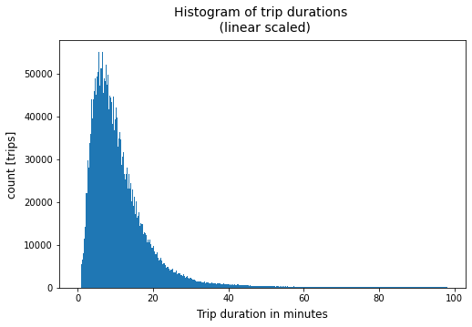

```python
# i will plot a linear scaled histogram of the "duration" column
plt.figure(figsize=[8, 5])
bins = np.arange(0, df['duration'].max()+0.2, 0.2)
plt.hist(data = df, x = 'duration', bins=bins);
plt.title('Histogram of trip durations \n (linear scaled)', fontsize=14, y=1.015)
plt.xlabel('Trip duration in minutes', labelpad=6, fontsize=12)
plt.ylabel('count [trips]', labelpad=6, fontsize=12)
plt.show()
```

The distriution is skewed to the right, i will apply a logarithimic transformation to the visualization.

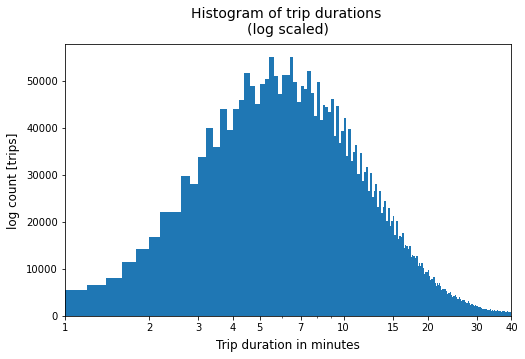

```python
# I applied a log scale to the x-axis.
# I increased the bin size to see and specified the ticks for the labels.
plt.figure(figsize=[8, 5])
bins = np.arange(0, 100, 0.2)
ticks = [1, 2, 3, 4, 5, 7, 10, 15, 20, 30, 40, 50, 90]
labels = ['{}'.format(v) for v in ticks]
plt.hist(data = df, x = 'duration', bins=bins);
plt.xscale('log')
plt.xticks(ticks, labels);
plt.xlim((1,40));
plt.title('Histogram of trip durations \n(log scaled)', fontsize=14, y=1.015)
plt.xlabel('Trip duration in minutes', labelpad=6, fontsize=12)
plt.ylabel('log count [trips]', labelpad=6, fontsize=12)
plt.show()
```

The distribution appears close to normal

### Insights

> The most common duration of trips is between 3 minutes to 10 minutes.

## B) Distance

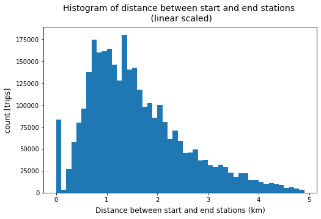

```python
# I will plot a linear scaled histogram to view the distribution of the distance.
plt.figure(figsize=[8,5])
bins = np.arange(0, 5, 0.1)
plt.hist(data = df, x = 'distance', bins=bins);
plt.title('Histogram of distance between start and end stations \n (linear scaled)', fontsize=14, y=1.015)
plt.xlabel('Distance between start and end stations (km)', labelpad=6, fontsize=12)
plt.ylabel('count [trips]', labelpad=6, fontsize=12)
plt.show()
```

The distribution is right-skewed indicating that in most cases, the distance between start and end stations is less than 4 kilometers even though we have trips stretching to the right with longer distances.

Since distance = 0 has enough frequency to consider it an important data point, I'll apply a symmetrical log transformation on the x-axis to avoid losing this value.

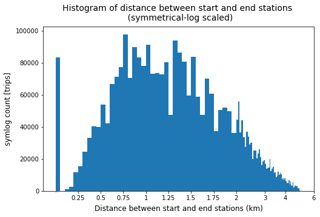

```python
# Applying symmetrical log scale (a lot of data = 0)
plt.figure(figsize=[8, 5])
bins = np.arange(0, 5, 0.05)
ticks = [0.25, 0.50, 0.75, 1, 1.25, 1.5, 1.75, 2, 3, 4, 6]
labels = ['{}'.format(v) for v in ticks]
plt.hist(data = df, x = 'distance', bins=bins);
plt.xscale('symlog')
plt.xticks(ticks, labels)
plt.title('Histogram of distance between start and end stations \n (symmetrical-log scaled)', fontsize=14, y=1.015)
plt.xlabel('Distance between start and end stations (km)', labelpad=6, fontsize=12)
plt.ylabel('symlog count [trips]', labelpad=6, fontsize=12)
plt.show()
```

This means that distance does not follow a normal distribution behavior.

The modal range of trip distance being around 0.75-1.5 kilometers.

### Insights

> Most trip distances is in the range of 0.75 to 1.5 kilometers.

## C) Start and End Stations

### 20 Most Popular Start Stations

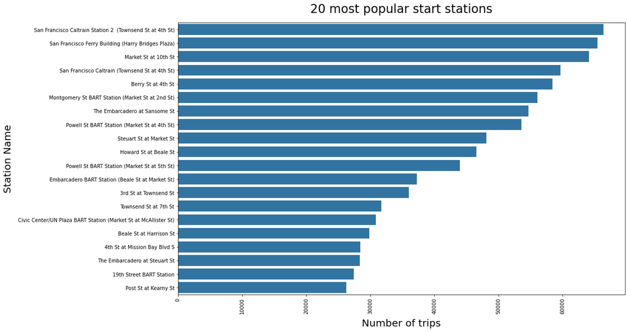

```python
# 20 most popular start stations
popular_start_stations = df['start_station_name'].value_counts()[:20]
rcParams['figure.figsize'] = 16,10
base_color = sns.color_palette()[0]
sns.barplot(x=popular_start_stations, y=popular_start_stations.index, color=base_color)
plt.title('20 most popular start stations', fontsize=24, y=1.025)
plt.xlabel('Number of trips', labelpad=10, fontsize=20)
plt.ylabel('Station Name', labelpad=10, fontsize=20)
# Use xticks to rotate the category labels (not axes) counter-clockwise
plt.xticks(rotation=90);
```

### 20 Most Popular End Stations

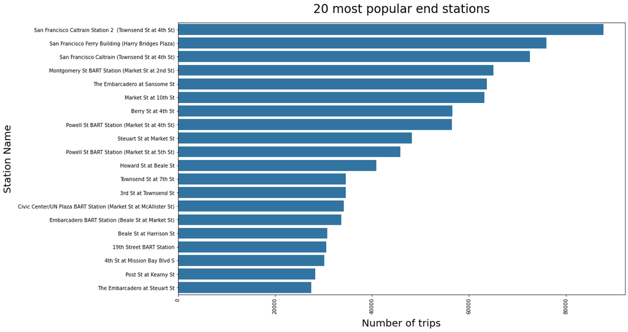

```python
#20 most popular end stations
popular_end_stations = df['end_station_name'].value_counts()[:20]
rcParams['figure.figsize'] = 16,10
base_color = sns.color_palette()[0]
sns.barplot(x=popular_end_stations, y=popular_end_stations.index, color=base_color)
plt.title('20 most popular end stations', fontsize=24, y=1.025)
plt.xlabel('Number of trips', labelpad=10, fontsize=20)
plt.ylabel('Station Name', labelpad=10, fontsize=20)
# Use xticks to rotate the category labels (not axes) counter-clockwise
plt.xticks(rotation=90);
```

### Insights

> The Popular Start Stations and the end Stations are quite similar which might mean that people use bikes to and fro the bike stations.

## C) Time trend Analysis

### Trips by Year

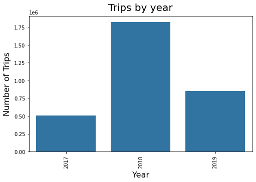

```python
# Total number of Bike rides per year
rcParams['figure.figsize'] = 8,5
base_color = sns.color_palette()[0]
sns.countplot(data=df, x=df['start_time'].dt.to_period('Y'), color = base_color);
plt.title('Trips by year', fontsize=20, y=1.015)
plt.xlabel('Year', labelpad=6, fontsize=16)
plt.ylabel('Number of Trips', labelpad=6, fontsize=16)
# Use xticks to rotate the category labels (not axes) counter-clockwise
plt.xticks(rotation=90);
```

#### PS

> The data only covers 6 months in 2017

> The data also only covers just 4 months in 2019

#### Insights

> There was an obvious growth from 2017-2019 accounting fOr the fact that there were 6 months in 2017 and 4 in 2019

### Trips by Months

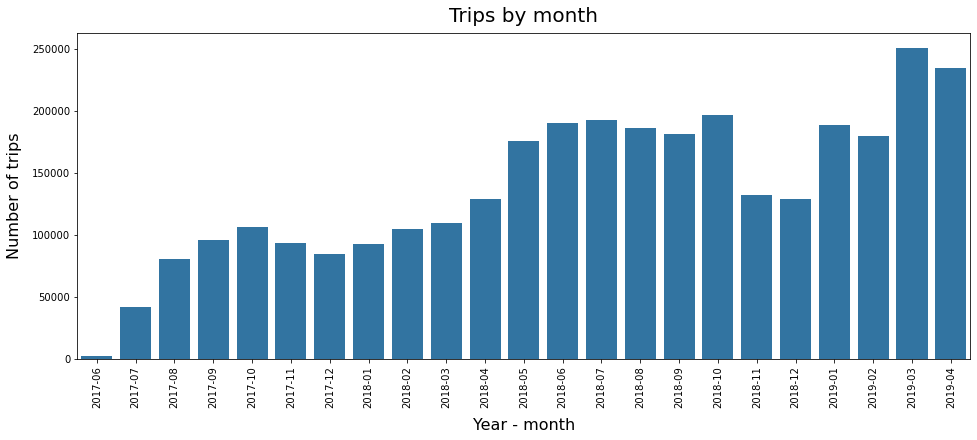

```python
# bike rides per month
rcParams['figure.figsize'] = 16,6
base_color = sns.color_palette()[0]
sns.countplot(data=df, x=df['start_time'].dt.to_period('M'), color = base_color);
plt.title('Trips by month', fontsize=20, y=1.015)
plt.xlabel('Year - month', labelpad=10, fontsize=16)
plt.ylabel('Number of trips', labelpad=10, fontsize=16)
# Use xticks to rotate the category labels (not axes) counter-clockwise
plt.xticks(rotation=90);
```

#### Insights

> There was an obvious growth over time.

> There are drops in rides in NovemberS and DecemberS and it needs further investigation.

### Trips by weekdays

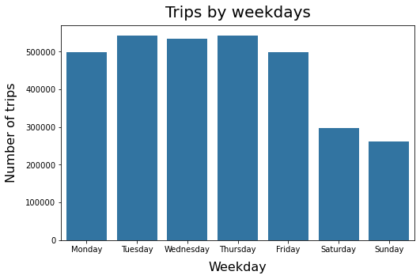

```python
# Bike rides per weekday
rcParams['figure.figsize'] = 8,5
base_color = sns.color_palette()[0]
weekday = ['Monday', 'Tuesday', 'Wednesday', 'Thursday', 'Friday', 'Saturday', 'Sunday']
sns.countplot(data=df, x=df['start_time'].dt.day_name(), order=weekday, color=base_color)
plt.title('Trips by weekdays', fontsize=20, y=1.015)
plt.xlabel('Weekday', labelpad=10, fontsize=16)
plt.ylabel('Number of trips', labelpad=10, fontsize=16);
```

#### Insights

> Trips dropped on weekends.

> Trips dropped slightly also on Monday and Friday.

### Trips by month days

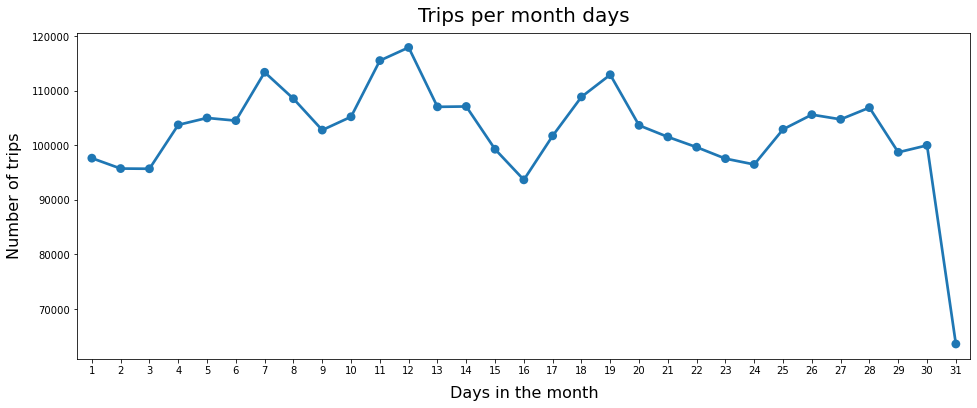

```python
# Days with most trips
trips_per_day = df['start_time'].dt.day.value_counts().sort_index()
# Point plot for daily rides
rcParams['figure.figsize'] = 16,6
sns.pointplot(x=trips_per_day.index, y=trips_per_day.values, color = base_color);
plt.title('Trips per month days', fontsize=20, y=1.015)
plt.xlabel('Days in the month', labelpad=10, fontsize=16)
plt.ylabel('Number of trips', labelpad=10, fontsize=16);
```

### Trips by hours of the day

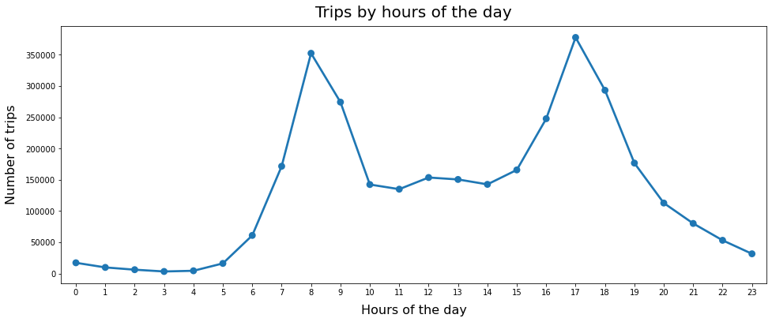

```python
# Hours with most trips
trips_per_hour = df['start_time'].dt.hour.value_counts().sort_index()
# Point plot for hourly rides
sns.pointplot(x=trips_per_hour.index, y=trips_per_hour.values, color = base_color);
plt.title('Trips by hours of the day', fontsize=20, y=1.015)
plt.xlabel('Hours of the day', labelpad=10, fontsize=16)
plt.ylabel('Number of trips', labelpad=10, fontsize=16);
```

#### Insights

> Trips peak around 8-9a.m in the morning and 5p.m and 6p.m.

> Trips are just average around 10a.m to 3p.m nd might be best tie to move bikes to popular start points from popular end points.

## D) User Type

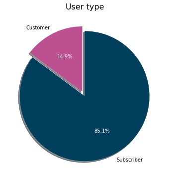

```python
# Percentage of users between subscribers and customers
# plotting the pie chart
_, _, autotexts = plt.pie(df['is_subscriber'].value_counts(), labels = ['Subscriber', 'Customer'],
        colors=['#003f5c', '#bc5090'], startangle = 90, counterclock = False, shadow = True,
        explode = (0, 0.08), radius = 1.0, autopct = '%1.1f%%')
# Change autopct text color to be white
for ins in autotexts:
    ins.set_color('white')
# Set plot title
plt.title('User type', fontsize=16, y=1.015)
plt.rcParams['font.size'] = 16
# showing the plot
plt.show()
```

## Insights - UNIVARIATE

> The most common duration of trips is between 3 minutes to 10 minutes.

> Most trip distances is in the range of 0.75 to 1.5 kilometers.

> The Popular Start Stations and the end Stations are quite similar which might mean that people use bikes to and fro the bike stations.

> There was an obvious growth over time.

> There are drops in rides in NovemberS and DecemberS and it needs further investigation.

> Trips dropped on weekends.

> Trips dropped slightly also on Monday and Friday.

> Trips peak around 8-9a.m in the morning and 5p.m and 6p.m.

> Trips are just average around 10a.m to 3p.m nd might be best tie to move bikes to popular start points from popular end points.

## 2) Bivariate Exploration

> In this section, I will investigate relationships between pairs of variables in the data. I will try to study the variables that i have explored individually in pairs with others to check for relationships.

## Overview

I will do a summary heatmap to show the correlation between all numeric variables

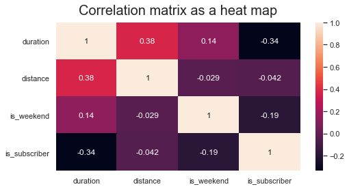

```python
# Check for linear correlation

corr_df = df.corr()
sns.set(rc={'figure.figsize':(8,4)})
sns.heatmap(corr_df, annot=True)
plt.title('Correlation matrix as a heat map', fontsize=20, y=1.025)
plt.show()
```

### Insights

> There is a positive correlation between Duration and Distance which shoud be further explored.

> There is a negative correlation between user type and trip duration which should be further explored.(a dummy variable entry column)

> There is a slight positive correlation between the trip duration anthe weekend column.

## A) Duration and Distance

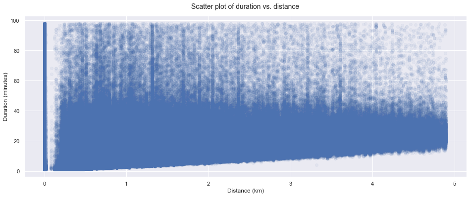

```python
# Scatter plot of duration vs. distance
plt.figure(figsize = [16, 6])
plt.scatter(data = df, x ='distance' , y = 'duration', alpha = 1/20)
plt.title('Scatter plot of duration vs. distance', fontsize=14, y=1.025)
plt.xlabel('Distance (km)')
plt.ylabel('Duration (minutes)')
plt.show()
```

> The dataset is large so it is difficult to picture the relationship

> I will use an heatmap and a representative sample data

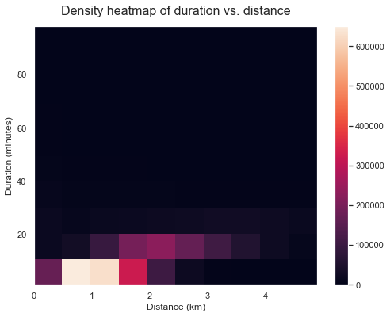

```python
# density heatmap of duration vs. distance
plt.figure(figsize = [8, 6])
plt.hist2d(data = df, x ='distance' , y = 'duration')
plt.title('Density heatmap of duration vs. distance', fontsize=16, y=1.025)
plt.xlabel('Distance (km)')
plt.ylabel('Duration (minutes)')
plt.colorbar()
plt.show()
```

> There is an obvious positive correlation between distance and trips below 30 minutes as expected, i will set a limit for better picture of the relationship

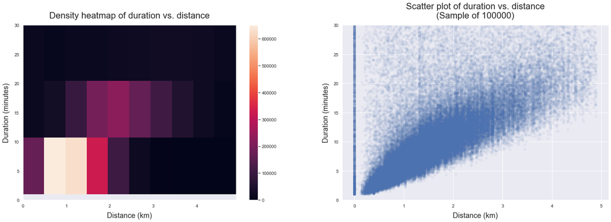

```python
# further investigate the relation at duration<=30

plt.figure(figsize = [26, 8])

# Density heatmap map of duration vs distance
plt.subplot(1, 2, 1)
plt.hist2d(data = df, x ='distance' , y = 'duration')
plt.ylim((0,30))
plt.title('Density heatmap of duration vs. distance', fontsize=22, y=1.025)
plt.xlabel('Distance (km)', labelpad=10, fontsize=18)
plt.ylabel('Duration (minutes)', labelpad=10, fontsize=18)
plt.colorbar()

# Scatter plot for duration vs distance, sample of 100000
plt.subplot(1, 2, 2)
sample_df = df.sample(n=100000)
plt.scatter(data = sample_df, x ='distance' , y = 'duration', alpha = 1/20)
plt.ylim((0,30))
plt.title('Scatter plot of duration vs. distance\n(Sample of 100000)', fontsize=22, y=1.025)
plt.xlabel('Distance (km)', labelpad=10, fontsize=18)
plt.ylabel('Duration (minutes)', labelpad=10, fontsize=18)
plt.show();
```

> The corelation between distance and duration is easier to view now.

> The is a strong positive correlation between duration less than 30 minutes and trip distance

```python
# let see the correlation coefficient between duration less than 30 minutes and distance

duration30 = df['duration'] <= 30
df['duration'][duration30].corr(df['distance'])
```

```
0.6937111758839314
```

### Insights

> There is a strong positive relationship between trips less than 30 minutes and trip geodesic distance with a correlation coefficient of 0.69.

## B) Duration and (Weekday or Workday)

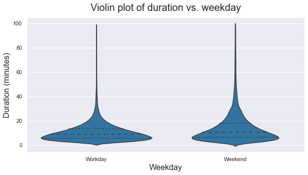

```python
# Violin plot of `duration` vs `is_weekend`
rcParams['figure.figsize'] = 10,5
sns.violinplot(data=df, x='is_weekend', y='duration', color = base_color, inner='quartile')
ticks = [0, 1]
labels = ['Workday', 'Weekend']
plt.xticks(ticks, labels)
plt.title('Violin plot of duration vs. weekday', fontsize=20, y=1.025)
plt.xlabel('Weekday', fontsize=16)
plt.ylabel('Duration (minutes)', fontsize=16);
```

> A Violin plot was used as the dataset is large.

### Insights

> People go on longer trips during weekends.

> There are more trips on workdays than weekends.

## B) Duration and User type (Customers or Subscribers)

### Distribution and charasteristics feature of user type

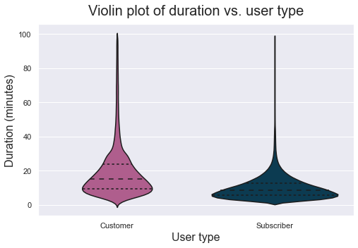

```python
# Violin plot of `is_subscriber` vs `duration`
# Customers tend to vary their trip durations, subscribers typically have short trips
rcParams['figure.figsize'] = 8,5
sns.violinplot(data=df, x='is_subscriber', y='duration', inner='quartile', palette=['#bc5090', '#003f5c'])
ticks = [0, 1]
labels = ['Customer', 'Subscriber']
plt.xticks(ticks, labels)
plt.title('Violin plot of duration vs. user type', fontsize=20, y=1.025)
plt.xlabel('User type', fontsize=16)
plt.ylabel('Duration (minutes)', fontsize=16);
```

#### Insight

> Customer go on longer trip durations than subscribers.

### Trip duration by months for user types

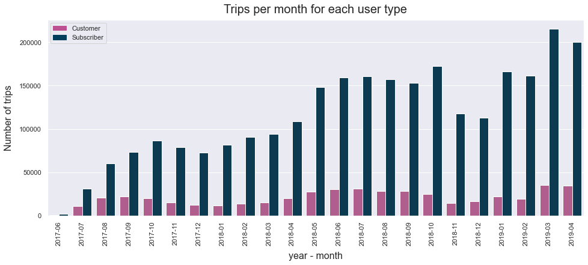

```python
# Bike rides per month for each user type
rcParams['figure.figsize'] = 16,6
sns.countplot(data=df, x=df['start_time'].dt.to_period('M'), hue='is_subscriber', palette=['#bc5090', '#003f5c'])
plt.title('Trips per month for each user type', fontsize=20, y=1.015)
plt.xlabel('year - month', labelpad=10, fontsize=16)
plt.ylabel('Number of trips', labelpad=10, fontsize=16)
# xticks to rotate the category labels (not axes) counter-clockwise
plt.xticks(rotation=90)
# Creating artists specifically for adding to the legend (Proxy artists)
customer_legend = mpatches.Patch(color='#bc5090', label='Customer')
subscriber_legend = mpatches.Patch(color='#003f5c', label='Subscriber')
plt.legend(handles=[customer_legend, subscriber_legend])
plt.show();
```

#### Insights

> There is similar trend in the patrionage by both Customers and Subscribers by months.

### Trips of user types by days of the month

I will be doing this as a percentage of the individual user types to have a comparable trend.

```python
# Creating masks for user type
customer = df['is_subscriber'] == 0
subscriber = df['is_subscriber'] == 1
# Days with most trips per user type
daily_trips_customer = (df.start_time[customer].dt.day.value_counts().sort_index())/df[customer].shape[0]
daily_trips_subscriber = (df.start_time[subscriber].dt.day.value_counts().sort_index())/df[subscriber].shape[0]
```

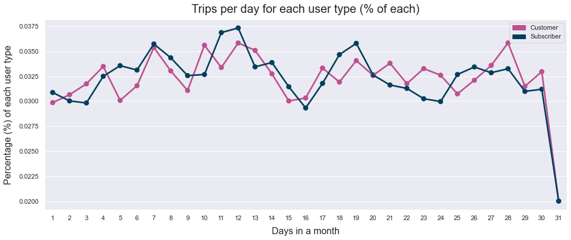

```python
# Point plot for daily rides per user type
rcParams['figure.figsize'] = 16,6
fig, ax = plt.subplots()
sns.pointplot(x=daily_trips_customer.index, y=daily_trips_customer.values, color='#bc5090')
sns.pointplot(x=daily_trips_subscriber.index, y=daily_trips_subscriber.values, color='#003f5c')
plt.title('Trips per day for each user type (% of each)', fontsize=20, y=1.015)
plt.xlabel('Days in a month', labelpad=10, fontsize=16)
plt.ylabel('Percentage (%) of each user type', labelpad=10, fontsize=16)
# Creating artists specifically for adding to the legend (Proxy artists)
customer_legend = mpatches.Patch(color='#bc5090', label='Customer')
subscriber_legend = mpatches.Patch(color='#003f5c', label='Subscriber')
plt.legend(handles=[customer_legend, subscriber_legend])
plt.show();
```

### Insights

> There is a similar trend in the patronage of both customers and subscribers within a month.

> Customers just tend to have sharp drops and peaks(flexibility of patronage) while subscribers have smoother drops and peaks( relatively better consisitency)

### Trips of user types by weekdays

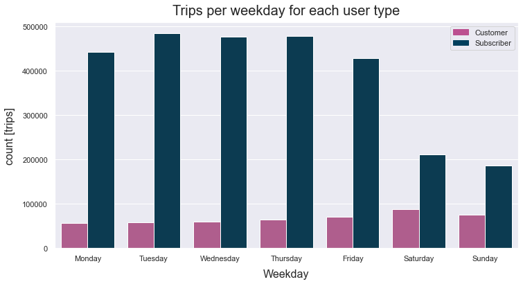

```python
# Bike rides per weekday for each user type
rcParams['figure.figsize'] = 12,6
weekday = ['Monday', 'Tuesday', 'Wednesday', 'Thursday', 'Friday', 'Saturday', 'Sunday']
sns.countplot(data=df, x=df['start_time'].dt.day_name(), hue='is_subscriber', order=weekday, palette=['#bc5090', '#003f5c'])
plt.title('Trips per weekday for each user type', fontsize=20, y=1.015)
plt.xlabel('Weekday', labelpad=10, fontsize=16)
plt.ylabel('count [trips]', labelpad=10, fontsize=16)
# Creating artists specifically for adding to the legend (Proxy artists)
customer_legend = mpatches.Patch(color='#bc5090', label='Customer')
subscriber_legend = mpatches.Patch(color='#003f5c', label='Subscriber')
plt.legend(handles=[customer_legend, subscriber_legend])
plt.show();
```

### Insights

> Customers patronize more on Fridays relative to subscribers.

> Customers also patronize more during weekends than than workdays.

### Trips of user types by hours of the day

I will be doing this as a percentage of the individual user types to have a comparable trend.

```python
# Creating masks for user type
customer = df['is_subscriber'] == 0
subscriber = df['is_subscriber'] == 1
# Days with most trips per user type
hourly_trips_customer = (df.start_time[customer].dt.hour.value_counts().sort_index())/df[customer].shape[0]
hourly_trips_subscriber = (df.start_time[subscriber].dt.hour.value_counts().sort_index())/df[subscriber].shape[0]
```

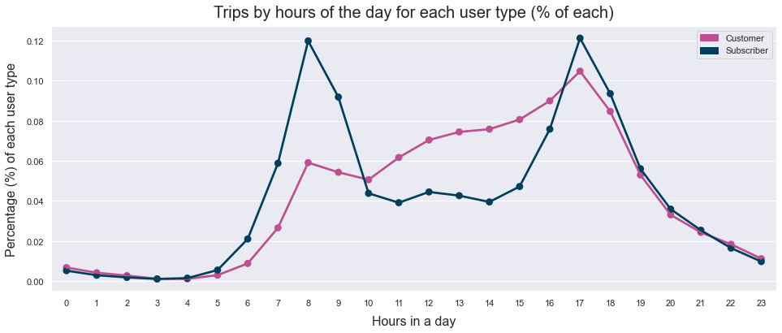

```python
# Point plot for daily rides per user type
rcParams['figure.figsize'] = 16,6
fig, ax = plt.subplots()
sns.pointplot(x=hourly_trips_customer.index, y=hourly_trips_customer.values, color='#bc5090')
sns.pointplot(x=hourly_trips_subscriber.index, y=hourly_trips_subscriber.values, color='#003f5c')
plt.title('Trips by hours of the day for each user type (% of each)', fontsize=20, y=1.015)
plt.xlabel('Hours in a day', labelpad=10, fontsize=16)
plt.ylabel('Percentage (%) of each user type', labelpad=10, fontsize=16)
# Creating artists specifically for adding to the legend (Proxy artists)
customer_legend = mpatches.Patch(color='#bc5090', label='Customer')
subscriber_legend = mpatches.Patch(color='#003f5c', label='Subscriber')
plt.legend(handles=[customer_legend, subscriber_legend])
plt.show();
```

### Insights

> There is a similar trend in the patronage of both customers and subscribers within a day.

> Customers just tend to patronize more around 10a.m to 3p.m relative to subscribers.

## Insights - BIVARIATE

> There is a strong positive relationship between trips less than 30 minutes and trip geodesic distance with a correlation coefficient of 0.69.

> People go on longer trips during weekends.

> There are more trips on workdays than weekends.

> Customer go on longer trip durations than subscribers.

> There is a similar trend in the patronage of both customers and subscribers within a month, Customers just tend to have sharp drops and peaks(flexibility of patronage) while subscribers have smoother drops and peaks( relatively better consisitency)

> Customers also patronize more on Fridays and weekends than other days.

> Customers just tend to patronize more around 10a.m to 3p.m relative to subscribers.

## 3) Multivariate Exploration

> I will create plots of three or more variables to investigate the data even further to justify investigations from your work in the previous sections.

### A) I will be visualizing the user types on a heatmap and checking for their individual correlation with pairs of three numeric variables( Duration, Distance and is_weekend)

I will be using duration limit of 30 minutes to reduce the effects of outliers as discovered in previous explorations.

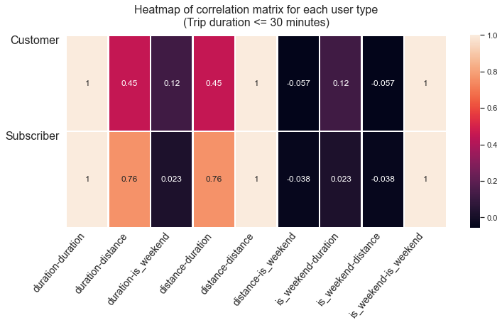

```python
# Heatmap for correlations between 'duration','distance, and 'is_weekend' for each user type
rcParams['figure.figsize'] = 12,5
# Create a mask for duration <= 30 minutes
duration30 = df['duration'] <= 30
num_cols = ['duration', 'distance', 'is_weekend']
corr_df = df[num_cols][duration30].groupby(df['is_subscriber']).corr()
sns.heatmap(corr_df.unstack(), annot=True, linewidths=1.5)
ticks = [0, 1]
labels = ['Customer', 'Subscriber']
plt.xticks(va='center_baseline', ha='right', rotation=50, fontsize=14)
plt.yticks(ticks, labels, va='top', ha='right', rotation=0, fontsize=16)
plt.title('Heatmap of correlation matrix for each user type\n(Trip duration <= 30 minutes)', fontsize=16, y=1.025)
plt.xlabel('', labelpad=10, fontsize=18)
plt.ylabel('', labelpad=10, fontsize=18)
plt.show()
```

#### Insights

> This further reveals that Customers go on longer trips than Subscribers during weekend.

> There is also a stronger correlation between distance, duration and Subscribers as compared to Customers. This is because for the customers there are longer trips duration, it will give a more scattered plot and lower correlation.

I will explore further this stringer correlation between Customers nd Subscribers on a subplot of heatmaps to visuslaize the cause.

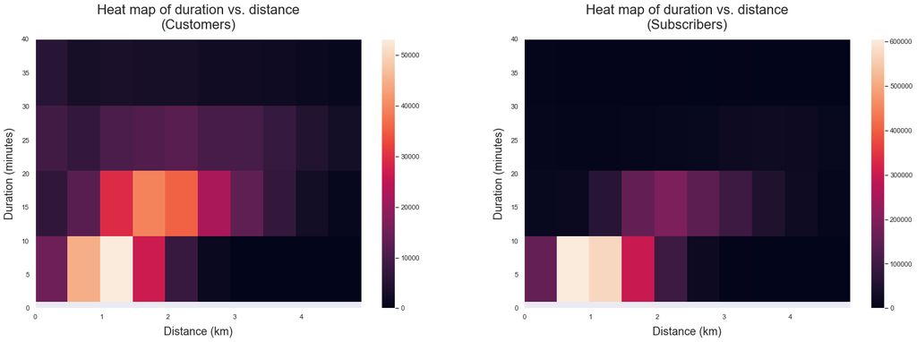

```python
# density heatmap of duration vs distance for each user type
# further investigate relation at duration<=40

plt.figure(figsize = [26, 8])

# Heat map of duration vs distance for customers
plt.subplot(1, 2, 1)
plt.hist2d(data = df, x =df.distance[customer] , y = df.duration[customer])
plt.ylim((0,40))
plt.title('Heat map of duration vs. distance\n(Customers)', fontsize=22, y=1.025)
plt.xlabel('Distance (km)', labelpad=10, fontsize=18)
plt.ylabel('Duration (minutes)', labelpad=10, fontsize=18)
plt.colorbar()

# Heat map of duration vs distance for subscribers
plt.subplot(1, 2, 2)
plt.hist2d(data = df, x =df.distance[subscriber], y = df.duration[subscriber])
plt.ylim((0,40))
plt.title('Heat map of duration vs. distance\n(Subscribers)', fontsize=22, y=1.025)
plt.xlabel('Distance (km)', labelpad=10, fontsize=18)
plt.ylabel('Duration (minutes)', labelpad=10, fontsize=18)
plt.colorbar()
plt.show();
```

#### Insights

> The Subscribers trips are mostly below 20 minutes while the Customers trips spread modally till about 35 minutes.

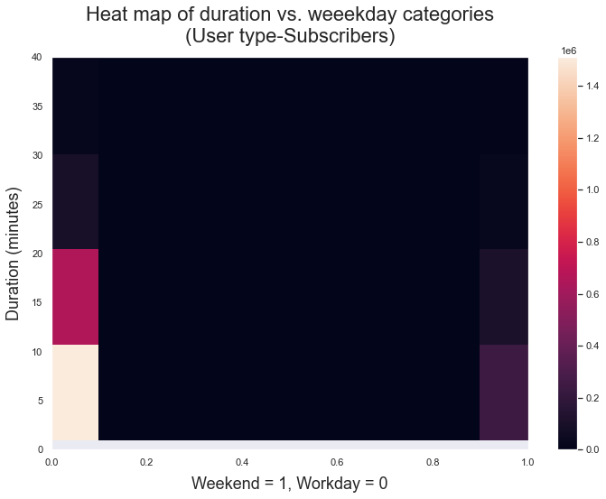

```python
# further investigate relation at duration<=40

plt.figure(figsize = [26, 8])
# Heat map of duration vs distance for subscribers
plt.subplot(1, 2, 2)
plt.hist2d(data = df, x =df.is_weekend[subscriber], y = df.duration[subscriber])
plt.ylim((0,40))
plt.title('Heat map of duration vs. weeekday categories\n(User type-Subscribers)', fontsize=22, y=1.025)
plt.xlabel('Weekend = 1, Workday = 0', labelpad=10, fontsize=18)
plt.ylabel('Duration (minutes)', labelpad=10, fontsize=18)
plt.colorbar()
plt.show();
```

## Insights - Multivariate

> This further reveals that Customers go on longer trips than Subscribers during weekend.

> There is also a stronger correlation between distance, duration and Subscribers as compared to Customers. This is because for the customers there are longer trips duration, it will give a more scattered plot and lower correlation.

> The Subscribers trips are mostly below 20 minutes while the Customers trips spread modally till about 35 minutes.

# Total Insights

> Most trips are within the duration of 3 minutes to 10 minutes.

> Most trip distances is in the range of 0.75 to 1.5 kilometers.

> The Popular Start Stations and the end Stations are quite similar which might mean that people use bikes to and fro the bike stations.

> There was an obvious growth in the patronage of Ford GoBike overtime as the number of trips per month shows a systematic increase overtime.

> There are drops in rides in all Novembers and Decembers which needs further investigation.

> Trips peak everyday around 8a.m-9a.m and 5p.m-6p.m which can mean that subscribers take bikes to work and take bikes back from work.

> Trips are just average around 10a.m to 3p.m and might be best time to move bikes to popular start points that have scarce bikes from popular end points.

> There are longer trips during weekends.

> There are more trips on workdays than weekends.

> Subscribers Patronize more on workdays than weekends.

> Customers also patronize more on Fridays and weekends than other days.

> There is also a stronger correlation between distance, duration and Subscribers as compared to Customers. This further establishes that for the customers there are longer trips duration which gives a more spread of trip duration and lower correlation.

> Though most customers also patronize with the same peaks of 8a.m to 9a.m and 5p.m to 6p.m, customers tend to patronize more around 10a.m to 3p.m relative to subscribers which might mean that customers have a more flexible patronage as expected.

> Customer go on longer trip durations than subscribers with the Subscribers trips mostly below 20 minutes while the Customers trips spread modally till about 35 minutes.

> It can be suspected that Customers love for long trips and more patronage during weekends is what results in longer trips during weekend.

> There is a similar trend in the patronage of both customers and subscribers within a month, Customers just tend to have sharp drops and peaks(flexibility of patronage) while subscribers have smoother drops and peaks( relatively better consisitency)